# Perfume data set - cluster analysis

## **Hierarchical Clustering**

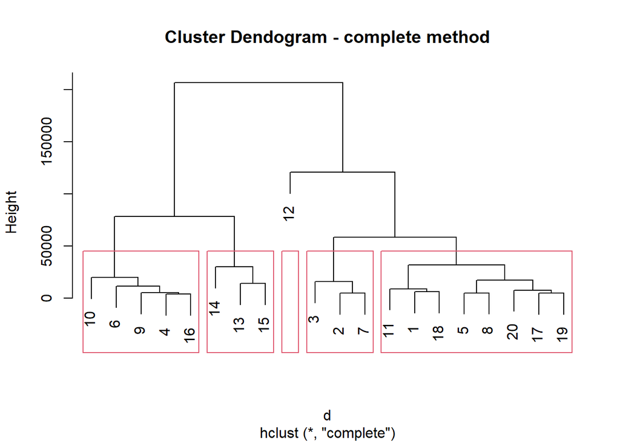

```r
library(stats)
library(ClustGeo)
d = dist(data)
hc = hclust(d, method = "complete")
plot(hc, main = "Cluster Dendogram - complete method")
rect.hclust(hc, k = 5)
```

```r
#checking the quality of the partitioning.
inertia = matrix(0, 4, 2)
cl_5 = cutree(hc, k=5)
cl_2 = cutree(hc, k = 2)
options("scipen"=100, "digits"=4)
```

One can see from the dendogram that 12th observation could be an outlier in our dataset, as it is not belong to any of the predefined clusters. Therefore, the same procedure will be done on the data with omitting 12th observation, as it is not included in the initial clustering. Dendogram could be a good tool to make a pre-analysis before trying any clustering algorithms, as we can see the whole picture of our data.

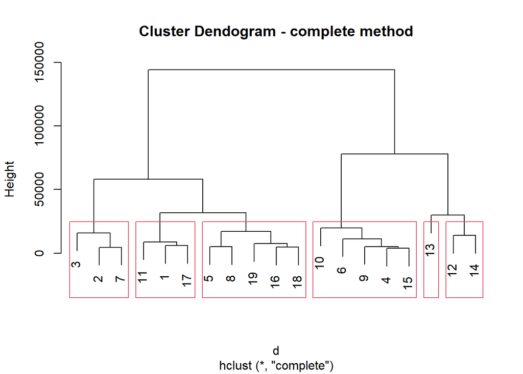

```r
d = dist(data[-12,])
hc = hclust(d, method = "complete")
plot(hc, main = "Cluster Dendogram - complete method")
rect.hclust(hc, k = 6)
```

```r
#checking the quality of the partitioning.
inertia = matrix(0, 4, 3)
cl_5 = cutree(hc, k = 5)
cl_2 = cutree(hc, k = 2)
cl_6 = cutree(hc, k = 6)
options("scipen"=100, "digits"=4)

inertia[1, 1] = withindiss(d, cl_5)
inertia[2, 1] = inertdiss(d)
inertia[3, 1]<-inertia[1,1]/ inertia[2,1]
inertia[4, 1]<-1-inertia[3,1]

inertia[1, 2] = withindiss(d, cl_6)
inertia[2, 2] = inertdiss(d)
inertia[3, 2]<-inertia[1,2]/ inertia[2,2]
inertia[4, 2]<-1-inertia[3,2]

inertia[1, 3] = withindiss(d, cl_2)
inertia[2, 3] = inertdiss(d)
inertia[3, 3]<-inertia[1,3]/ inertia[2,3]
inertia[4, 3]<-1-inertia[3,3]


colnames(inertia) = c("5 clusters", "6 clusters", "2 cluster")
rownames(inertia) = c("intra-clust", "total", "percentage", "Q")
inertia
```

```
##                   5 clusters       6 clusters       2 cluster
## intra-clust   58380581.28421   39874861.14386  510409677.5239
## total       1432878440.49861 1432878440.49861 1432878440.4986
## percentage           0.04074          0.02783          0.3562
## Q                    0.95926          0.97217          0.6438
```

After executing hierarchical clustering on the data excluding 12th observation, we can notice some improvements. I decided to count inertia for 6, 5 and 2 clusters. Partitioning into 6 clusters could improve our results. In case of partitioning into 6 clusters, within-clusters diversity is almost 3% and inter clusters diversity is 97% comparing to the results from 5 clusters partitioning where 4% and 96% respectively.

## **Model-Based clustering in R**

```r
library(mclust)
mc = Mclust(data)
summary(mc)
```

```
## ----------------------------------------------------
## Gaussian finite mixture model fitted by EM algorithm
## ----------------------------------------------------
##
## Mclust EII (spherical, equal volume) model with 9 components:
##
##  log-likelihood  n  df    BIC    ICL
##           -4638 20 261 -10058 -10058
##
## Clustering table:
## 1 2 3 4 5 6 7 8 9
## 4 2 1 2 4 1 2 1 3
```

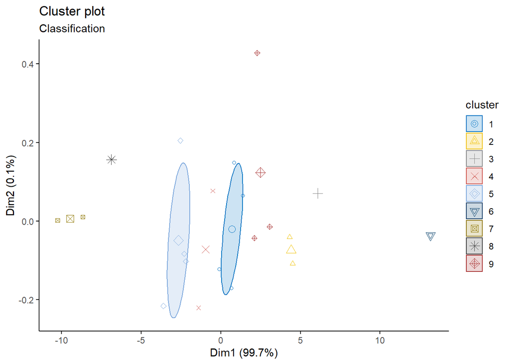

```r
fviz_mclust(mc, "classification", geom = "point",
            pointsize = 1.5, palette = "jco")
```

Model-based clustering assumes that our data comes from the specific distributions. The algorithms of the function is trying to fits different distributions to the the data and as a results each cluster will be fitted to different distribution, as it is assumed that observations are coming from different distributions. Comparing to previous methods it tries to measure the probability of belonging of each observation to the cluster. After computing model-based clustering we can notice that our data is not clustered well, as it is probably comes from the same distribution. So, only few point are clustered into two clusters. From the summary of the function we can see that spherical, equal volume model was fitted to the data with 9 clusters in total. I think small sample of 20 observations makes it difficult to analyze the this method. Graph shows that we discovered 9 models from which data was generated. We can see two bigger clusters (1 and 5) that are represented in the form of the ellips.

## **Statistics in clustered groups**

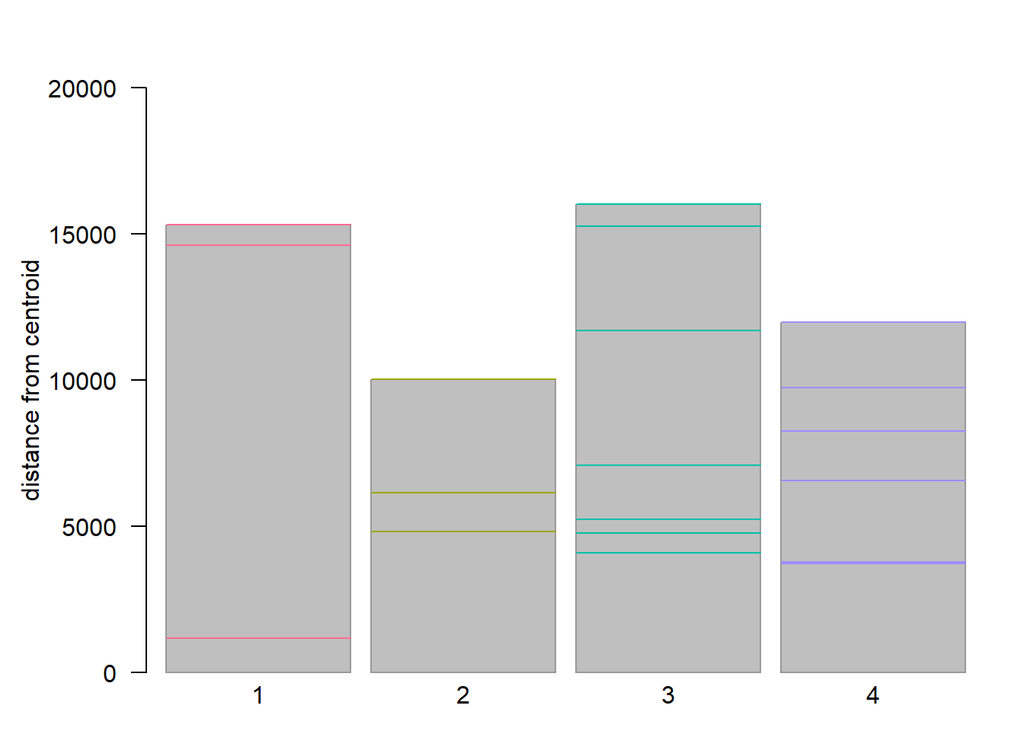

```r
library(flexclust)
d1<-cclust(data[-12,], 4, dist="euclidean")
stripes(d1)
```

From the graph we can say that in 3rd cluster our fragrances are the most distant from centroid within given cluster. First and second clusters consist of 3 observations only.Observations in the first cluster are very distant from the centroid.